# Project_Full_Code_Notebook_EasyVisa

# **Model Building**

### Model Evaluation Criterion

There are two ways model can make wrong predictions:

> - Model predicts that the visa application will get certified but actually it should get denied.
> - Model predicts that the visa application will not get certified but actually it should get certified.

Both the cases are important because (1) if a visa is certified when it had to be denied a wrong employee will get the job position while US citizens will miss the opportunity to work on that position. (2) if a visa is denied when it had to be certified the U.S. will lose a suitable human resource that can contribute to the economy.

Therefore to minimize false negatives (FN) and false positives (FP), we are going to use `F1 Score` metric for evaluation of the model. We will use balanced class weights so that model focuses equally on both classes.

```python
# Function to compute different metrics to check performance of a classification model built using sklearn
def model_performance_classification(model, predictors, target):
    """
    Function to compute different metrics to check classification model performance

    model: classifier
    predictors: independent variables
    target: dependent variable
    """

    # predicting using the independent variables
    pred = model.predict(predictors)

    acc = accuracy_score(target, pred)  # to compute Accuracy
    recall = recall_score(target, pred)  # to compute Recall
    precision = precision_score(target, pred)  # to compute Precision
    f1 = f1_score(target, pred)  # to compute F1-score

    # creating a dataframe of metrics
    df_perf = pd.DataFrame(
        {"Accuracy": acc, "Recall": recall, "Precision": precision, "F1": f1,},
        index=[0],
    )

    return df_perf
```

```python
# Funtion to plot Confusion matrix
def confusion_matrix_sklearn(model, predictors, target):
    """
    To plot the confusion_matrix with percentages

    model: classifier
    predictors: independent variables
    target: dependent variable
    """
    y_pred = model.predict(predictors)
    cm = confusion_matrix(target, y_pred)
    labels = np.asarray(
        [
            ["{0:0.0f}".format(item) + "\n{0:.2%}".format(item / cm.flatten().sum())]
            for item in cm.flatten()
        ]
    ).reshape(2, 2)

    plt.figure(figsize=(6, 4))
    sns.heatmap(cm, annot=labels, fmt="")
    plt.ylabel("True label")
    plt.xlabel("Predicted label")
```

```python
# Function to plot feature importance
def plot_feature_importance(model, feature_names, title="Feature Importance Ranking"):
    """
    Plot sorted feature importances for a tree-based model.

    Parameters
    ----------
    model : sklearn-like model
        A fitted model with the attribute `.feature_importances_`
        (e.g., DecisionTreeClassifier, RandomForestClassifier).

    feature_names : list of str
        Names of the input features in the same order as the model was trained.

    title : str, optional
        Title of the plot (default: "Feature Importance Ranking").
    """

    # Extract feature importances from model
    importances = model.feature_importances_

    # Sort importances (small -> large) and reorder feature names
    indices = np.argsort(importances)
    sorted_features = [feature_names[i] for i in indices]
    sorted_importances = importances[indices]

    # Create figure
    plt.figure(figsize=(10, 8))
    plt.title(title, fontsize=16, fontweight="bold", pad=15)

    # Plot horizontal bar chart
    sns.barplot(
        x=sorted_importances,
        y=sorted_features,
        palette="viridis"
    )

    # Axis labels
    plt.xlabel("Importance Score", fontsize=12)
    plt.ylabel("Feature Name", fontsize=12)

    # Add numeric annotation to each bar
    for i, val in enumerate(sorted_importances):
        plt.text(
            val + 0.005,   # offset to avoid overlapping the bar
            i,
            f"{val:.3f}",
            fontsize=10,
            va="center"
        )

    # Add grid for better readability
    plt.grid(axis="x", linestyle="--", alpha=0.4)

    plt.tight_layout()
    plt.show()
```

```python
# Method to evaluate models
def evaluate_models(models, X_train, y_train, X_test, y_test):
    """
    Fits multiple models, computes metrics using model_performance_classification_sklearn,
    and prints a consolidated results table.
    """
    all_results = []

    # Handle dictionary input
    items = models.items() if isinstance(models, dict) else models

    for name, model in items:
        # Fit once
        model.fit(X_train, y_train)

        # Get Train performance
        df_train = model_performance_classification(model, X_train, y_train)
        df_train.insert(0, "Set", "Train")   # Label the row
        df_train.insert(0, "Model", name)    # Label the model

        # Get Validation performance
        df_val = model_performance_classification(model, X_val, y_val)
        df_val.insert(0, "Set", "Validation")
        df_val.insert(0, "Model", name)

        # Get Test performance
        df_test = model_performance_classification(model, X_test, y_test)
        df_test.insert(0, "Set", "Test")
        df_test.insert(0, "Model", name)

        # Collect results
        all_results.append(df_train)
        all_results.append(df_val)
        all_results.append(df_test)

    # Combine all individual dataframes into one
    comparison_df = pd.concat(all_results, ignore_index=True)

    return comparison_df
```

### Model Building

```python
# Create a list of models
models = {
    "DecisionTree": DecisionTreeClassifier(random_state=1, class_weight='balanced'),
    "RandomForest": RandomForestClassifier(random_state=1, class_weight='balanced', n_jobs=-1),
    "BaggingTree": BaggingClassifier(estimator=DecisionTreeClassifier(random_state=1, class_weight='balanced'), random_state=1, n_jobs=-1),
    "AdaBoost": AdaBoostClassifier(random_state=1),
    "GradientBoosting": GradientBoostingClassifier(random_state=1),
    "XGBoost": XGBClassifier(random_state=1, eval_metric="logloss", n_jobs=-1,)
}
```

#### Model Building - Original Data

```python
# Evaluate all the models using the original data
rows = []
for model_name, model in models.items():
    newModel = clone(model)
    newModel.fit(X_train, y_train)

    # Train
    df_train = model_performance_classification(newModel, X_train, y_train).copy()
    df_train.insert(0, "Set", "Train")
    df_train.insert(0, "Model", model_name)
    rows.append(df_train)

    # Validation
    df_val = model_performance_classification(newModel, X_val, y_val).copy()
    df_val.insert(0, "Set", "Validation")
    df_val.insert(0, "Model", model_name)
    rows.append(df_val)

perf_df = pd.concat(rows, ignore_index=True)
perf_df
```

|  | Model | Set | Accuracy | Recall | Precision | F1 |
| --- | --- | --- | --- | --- | --- | --- |
| 0 | DecisionTree | Train | 1.000000 | 1.000000 | 1.000000 | 1.000000 |
| 1 | DecisionTree | Validation | 0.660911 | 0.744712 | 0.746906 | 0.745808 |
| 2 | RandomForest | Train | 1.000000 | 1.000000 | 1.000000 | 1.000000 |
| 3 | RandomForest | Validation | 0.720565 | 0.833725 | 0.767857 | 0.799437 |
| 4 | BaggingTree | Train | 0.986133 | 0.988834 | 0.990387 | 0.989610 |
| 5 | BaggingTree | Validation | 0.697017 | 0.775264 | 0.772089 | 0.773673 |
| 6 | AdaBoost | Train | 0.740319 | 0.888247 | 0.762229 | 0.820427 |
| 7 | AdaBoost | Validation | 0.738226 | 0.880729 | 0.763627 | 0.818008 |
| 8 | GradientBoosting | Train | 0.758046 | 0.878942 | 0.784646 | 0.829122 |
| 9 | GradientBoosting | Validation | 0.755298 | 0.873384 | 0.784640 | 0.826637 |
| 10 | XGBoost | Train | 0.855704 | 0.942801 | 0.855797 | 0.897195 |
| 11 | XGBoost | Validation | 0.727826 | 0.848414 | 0.768289 | 0.806366 |

- On the original (imbalanced) dataset, the strongest validation performance comes from the boosting models. Gradient Boosting achieved the best validation performance, with the highest Accuracy (0.7553) and F1-score (0.8266) and a strong balance of Recall (0.8734) and Precision (0.7846). AdaBoost is the second-best performer (F1 = 0.8180) with very high Recall (0.8807) while maintaining reasonable Precision (0.7636). XGBoost remains competitive (F1 = 0.8064) but does not outperform the two boosting models.
- Among the non-boosting ensembles, Random Forest performs solidly (F1 = 0.7994, Accuracy = 0.7206), while Bagging achieves (F1 = 0.7737, Accuracy = 0.6970). The standalone Decision Tree is weaker on validation (F1 = 0.7458, Accuracy = 0.6609).
- In terms of generalization, the Decision Tree and Random Forest show perfect training scores (F1 = 1.00) with noticeably lower validation performance, indicating overfitting. Bagging reduces overfitting compared to a single tree but still shows a train–validation gap. Overall, the boosting models—especially Gradient Boosting—demonstrate the most consistent train–validation behavior and the strongest generalization, making them the best candidates to carry forward into oversampling/undersampling comparisons and hyperparameter tuning.

#### Model Building - Undersampled Data

```python
# Evaluate all the models using the undersampled data
rows = []
for model_name, model in models.items():
    newModel = clone(model)
    newModel.fit(X_train_under, y_train_under)

    # Train
    df_train = model_performance_classification(newModel, X_train_under, y_train_under).copy()
    df_train.insert(0, "Set", "Train")
    df_train.insert(0, "Model", model_name)
    rows.append(df_train)

    # Validation
    df_val = model_performance_classification(newModel, X_val, y_val).copy()
    df_val.insert(0, "Set", "Validation")
    df_val.insert(0, "Model", model_name)
    rows.append(df_val)

perf_df = pd.concat(rows, ignore_index=True)
perf_df
```

|  | Model | Set | Accuracy | Recall | Precision | F1 |
| --- | --- | --- | --- | --- | --- | --- |
| 0 | DecisionTree | Train | 1.000000 | 1.000000 | 1.000000 | 1.000000 |
| 1 | DecisionTree | Validation | 0.623626 | 0.626910 | 0.767074 | 0.689945 |
| 2 | RandomForest | Train | 1.000000 | 1.000000 | 1.000000 | 1.000000 |
| 3 | RandomForest | Validation | 0.683673 | 0.673032 | 0.821147 | 0.739748 |
| 4 | BaggingTree | Train | 0.980307 | 0.968295 | 0.992131 | 0.980068 |
| 5 | BaggingTree | Validation | 0.658556 | 0.616040 | 0.828854 | 0.706775 |
| 6 | AdaBoost | Train | 0.695451 | 0.715833 | 0.687796 | 0.701534 |
| 7 | AdaBoost | Validation | 0.707810 | 0.715922 | 0.823589 | 0.765991 |
| 8 | GradientBoosting | Train | 0.720756 | 0.747932 | 0.709376 | 0.728144 |
| 9 | GradientBoosting | Validation | 0.719780 | 0.729142 | 0.830656 | 0.776596 |
| 10 | XGBoost | Train | 0.870914 | 0.879677 | 0.864525 | 0.872035 |
| 11 | XGBoost | Validation | 0.687794 | 0.686839 | 0.816626 | 0.746131 |

- On the undersampled training data, the boosting models delivered the strongest validation performance. Gradient Boosting achieved the the best overall validation results (Accuracy = 0.7198, F1 = 0.7766), maintaining a good balance of Recall (0.7291) and Precision (0.8307). AdaBoost follows closely (F1 = 0.7660) with strong precision (0.8236) and slightly lower recall (0.7159). XGBoost performs moderately well (F1 = 0.7461) and is comparable to Random Forest (F1 = 0.7397), but both remain below the two boosting models. Bagging (F1 = 0.7068) and the standalone Decision Tree (F1 = 0.6899) produced the weakest validation results.
- In terms of generalization, the Decision Tree and Random Forest still show perfect training scores (F1 = 1.00) with noticeably lower validation results, indicating continued overfitting, whereas boosting models show more realistic training performance and better stability. Overall, undersampling still produces weaker results than the best performance achieved on the original training strategies, suggesting that removing majority class samples likely discards useful information and limits overall generalization.

#### Model Building - Oversampled Data

```python
# Evaluate all the models using the oversampled data
rows = []
for model_name, model in models.items():
    newModel = clone(model)
    newModel.fit(X_train_over, y_train_over)

    # Train
    df_train = model_performance_classification(newModel, X_train_over, y_train_over).copy()
    df_train.insert(0, "Set", "Train")
    df_train.insert(0, "Model", model_name)
    rows.append(df_train)

    # Validation
    df_val = model_performance_classification(newModel, X_val, y_val).copy()
    df_val.insert(0, "Set", "Validation")
    df_val.insert(0, "Model", model_name)
    rows.append(df_val)

perf_df = pd.concat(rows, ignore_index=True)
perf_df
```

|  | Model | Set | Accuracy | Recall | Precision | F1 |
| --- | --- | --- | --- | --- | --- | --- |
| 0 | DecisionTree | Train | 1.000000 | 1.000000 | 1.000000 | 1.000000 |
| 1 | DecisionTree | Validation | 0.658556 | 0.740012 | 0.746592 | 0.743287 |
| 2 | RandomForest | Train | 0.999951 | 1.000000 | 0.999902 | 0.999951 |
| 3 | RandomForest | Validation | 0.725667 | 0.830200 | 0.775096 | 0.801702 |
| 4 | BaggingTree | Train | 0.988492 | 0.986288 | 0.990654 | 0.988466 |
| 5 | BaggingTree | Validation | 0.695055 | 0.765570 | 0.775134 | 0.770322 |
| 6 | AdaBoost | Train | 0.801371 | 0.865622 | 0.767054 | 0.813363 |
| 7 | AdaBoost | Validation | 0.743132 | 0.862221 | 0.777483 | 0.817663 |
| 8 | GradientBoosting | Train | 0.812537 | 0.859647 | 0.785625 | 0.820971 |
| 9 | GradientBoosting | Validation | 0.750000 | 0.850764 | 0.790825 | 0.819700 |
| 10 | XGBoost | Train | 0.879677 | 0.927424 | 0.846580 | 0.885160 |
| 11 | XGBoost | Validation | 0.734301 | 0.849589 | 0.774505 | 0.810311 |

- On the oversampled (SMOTE) training data, the boosting models continued to deliver the strongest and most stable validation performance. Gradient Boosting achieved the best overall results (Accuracy = 0.7500, F1 = 0.8197) with a strong balance of Recall (0.8508) and Precision (0.7908). AdaBoost followed very closely (F1 = 0.8177) and achieved the highest recall (0.8622) among the models, while XGBoost was also competitive (F1 = 0.8103) with high recall (0.8496) and solid precision (0.7745). Random Forest performed well (F1 = 0.8017) but remained below the top boosting models, while Bagging (F1 = 0.7703) and the standalone Decision Tree (F1 = 0.7433) were comparatively weaker.
- In terms of generalization, the Decision Tree and Random Forest show near-perfect training performance with noticeably lower validation results, indicating overfitting, whereas the boosting models display more realistic training performance and smaller train–validation gaps. Overall, SMOTE oversampling preserved strong validation performance while addressing class imbalance, making it a suitable strategy for proceeding to hyperparameter tuning.

#### Original vs Undersampled vs Oversampled — Comparison Summary

Across all three training strategies, boosting models consistently delivered the best validation performance, indicating they capture the strongest patterns in the data while generalizing better than single-tree and bagging-based approaches.

- Original (imbalanced) data produced the strongest overall validation results, with Gradient Boosting achieving the best performance (F1 = 0.8266, Accuracy = 0.7553), followed closely by AdaBoost (F1 = 0.8180) and XGBoost (F1 = 0.8064). This suggests the models are able to learn meaningful decision boundaries even without resampling, although class imbalance remains a concern operationally.
- Oversampling (SMOTE) produced validation performance that was very close to the original strategy, with Gradient Boosting again leading (F1 = 0.8197, Accuracy = 0.7500) and AdaBoost (F1 = 0.8177) and XGBoost (F1 = 0.8103) also performing strongly. SMOTE maintains most of the original predictive power while improving class balance during training, making it a reliable approach for tuning.
- Undersampling consistently resulted in the weakest performance, even though boosting models still ranked highest. The best undersampled model (Gradient Boosting) dropped to F1 = 0.7766 (Accuracy = 0.7198), indicating that removing majority-class examples likely discarded useful information and reduced generalization.

**Overall, the results show that undersampling is not optimal for this dataset, while original and SMOTE strategies both perform strongly, with SMOTE offering the added benefit of addressing imbalance without sacrificing much predictive performance.**

Based on consistent top performance across strategies and strong validation metrics, the three models selected for hyperparameter tuning are:

- **Gradient Boosting (best overall validation performance across all strategies)**
- **AdaBoost (second-best, with consistently high recall and competitive F1)**
- **XGBoost (strong performance and competitive F1, especially under SMOTE)**

# **Model Performance Improvement**

### **Note**

1. Sample parameter grids have been provided to do necessary hyperparameter tuning. These sample grids are expected to provide a balance between model performance improvement and execution time. One can extend/reduce the parameter grid based on execution time and system configuration.
- Please note that if the parameter grid is extended to improve the model performance further, the execution time will increase
2. The models chosen in this notebook are based on test runs. One can update the best models as obtained upon code execution and tune them for best performance.
- For Gradient Boosting:

```
param_grid = {
    "init": [AdaBoostClassifier(random_state=1),DecisionTreeClassifier(random_state=1)],
    "n_estimators": np.arange(50,110,25),
    "learning_rate": [0.01,0.1,0.05],
    "subsample":[0.7,0.9],
    "max_features":[0.5,0.7,1],
}
```

- For Adaboost:

```
param_grid = {
    "n_estimators": np.arange(50,110,25),
    "learning_rate": [0.01,0.1,0.05],
    "base_estimator": [
        DecisionTreeClassifier(max_depth=2, random_state=1),
        DecisionTreeClassifier(max_depth=3, random_state=1),
    ],
}
```

- For Bagging Classifier:

```
param_grid = {
    'max_samples': [0.8,0.9,1],
    'max_features': [0.7,0.8,0.9],
    'n_estimators' : [30,50,70],
}
```

- For Random Forest:

```
param_grid = {
    "n_estimators": [50,110,25],
    "min_samples_leaf": np.arange(1, 4),
    "max_features": [np.arange(0.3, 0.6, 0.1),'sqrt'],
    "max_samples": np.arange(0.4, 0.7, 0.1)
}
```

- For Decision Trees:

```
param_grid = {
    'max_depth': np.arange(2,6),
    'min_samples_leaf': [1, 4, 7],
    'max_leaf_nodes' : [10, 15],
    'min_impurity_decrease': [0.0001,0.001]
}
```

- For XGBoost:

```
param_grid={'n_estimators':np.arange(50,110,25),
            'scale_pos_weight':[1,2,5],
            'learning_rate':[0.01,0.1,0.05],
            'gamma':[1,3],
            'subsample':[0.7,0.9]
}
```

### Hyperparameter Tuning - AdaBoost

```python
# Model name
model_name = "AdaBoost"

# Create instance of the model
tuned_adaboost_model = clone(models[model_name])

# Set hyperparameters
param_grid = {
    "n_estimators": np.arange(50,110,25),
    "learning_rate": [0.01,0.1,0.05],
    "estimator": [
        DecisionTreeClassifier(max_depth=2, random_state=1),
        DecisionTreeClassifier(max_depth=3, random_state=1),
    ],
}

# Set the randomaized serarch model and parameters
gs_ab = GridSearchCV(estimator=tuned_adaboost_model, param_grid=param_grid, scoring="f1", cv=5, n_jobs=-1)

# Fit the training (oversampled) dataset
gs_ab = gs_ab.fit(X_train_over, y_train_over)

# Get the best estimator
tuned_adaboost_model = gs_ab.best_estimator_

# Fit the best estimator to the data
tuned_adaboost_model.fit(X_train_over, y_train_over)

print("Best Params (AdaBoost):", gs_ab.best_params_)
print("Best CV F1 (AdaBoost):", gs_ab.best_score_)
```

```
Best Params (AdaBoost): {'estimator': DecisionTreeClassifier(max_depth=3, random_state=1), 'learning_rate': 0.1, 'n_estimators': np.int64(100)}
Best CV F1 (AdaBoost): 0.8032333354759457
```

#### Checking Model Performance on Training (Oversampled) Data

|  | Accuracy | Recall | Precision | F1 |
| --- | --- | --- | --- | --- |
| 0 | 0.801763 | 0.845348 | 0.777568 | 0.810042 |

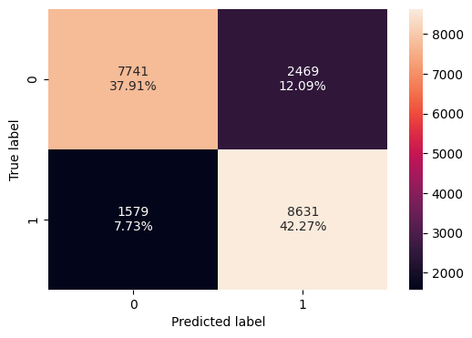

```python
# Checking model performance on training set
confusion_matrix_sklearn(tuned_adaboost_model, X_train_over, y_train_over)
tuned_adaboost_train_perf = model_performance_classification(tuned_adaboost_model, X_train_over, y_train_over).copy()
tuned_adaboost_train_perf
```

- The training confusion matrix shows strong overall fit with a relatively high number of correctly classified approvals and denials, though some errors remain which indicates the model is learning meaningful patterns without being unrealistically perfect.

#### Checking Model Performance on Validation Set

|  | Accuracy | Recall | Precision | F1 |
| --- | --- | --- | --- | --- |
| 0 | 0.748626 | 0.8396 | 0.795436 | 0.816922 |

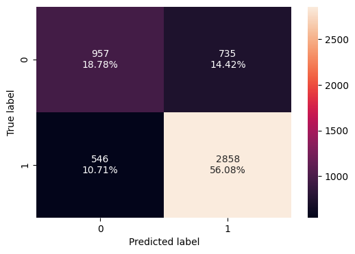

```python
# Checking model performance on validation set
confusion_matrix_sklearn(tuned_adaboost_model, X_val, y_val)
tuned_adaboost_val_perf = model_performance_classification(tuned_adaboost_model, X_val, y_val).copy()
tuned_adaboost_val_perf
```

- On the validation set, the tuned AdaBoost model maintains strong generalization, with an F1-score above 0.81 and a good balance between recall and precision. The validation confusion matrix suggests the model is particularly effective at identifying Approved cases (high recall), while still maintaining solid precision which means a large fraction of predicted approvals are truly approved.

### Hyperparameter Tuning - GradientBoosting

```python
# Model name
model_name = "GradientBoosting"

# Create instance of the model
tuned_gradient_boosting_model = clone(models[model_name])

# Set hyperparameters
param_grid = {
    "init": [AdaBoostClassifier(random_state=1),DecisionTreeClassifier(random_state=1)],
    "n_estimators": np.arange(50,110,25),
    "learning_rate": [0.01,0.1,0.05],
    "subsample":[0.7,0.9],
    "max_features":[0.5,0.7,1],
}

# Set the randomaized serarch model and parameters
gs_gb = GridSearchCV(estimator=tuned_gradient_boosting_model, param_grid=param_grid, scoring="f1", cv=5, n_jobs=-1)

# Fit the training (oversampled) dataset
gs_gb = gs_gb.fit(X_train_over, y_train_over)

# Get the best estimator
tuned_gradient_boosting_model = gs_gb.best_estimator_

# Fit the best estimator to the data
tuned_gradient_boosting_model.fit(X_train_over, y_train_over)

print("Best Params (GradientBoosting):", gs_gb.best_params_)
print("Best CV F1 (GradientBoosting):", gs_gb.best_score_)
```

```
Best Params (GradientBoosting): {'init': AdaBoostClassifier(random_state=1), 'learning_rate': 0.05, 'max_features': 1, 'n_estimators': np.int64(75), 'subsample': 0.9}
Best CV F1 (GradientBoosting): 0.8170282289556352
```

|  | Accuracy | Recall | Precision | F1 |
| --- | --- | --- | --- | --- |
| 0 | 0.746402 | 0.861802 | 0.781092 | 0.819464 |

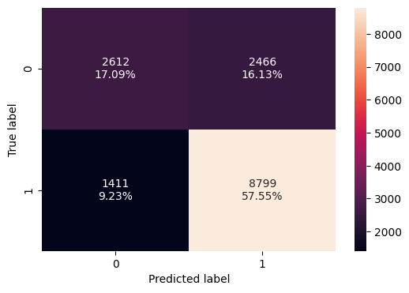

```python
# Checking model performance on training set
confusion_matrix_sklearn(tuned_gradient_boosting_model, X_train, y_train)
tuned_gradient_boosting_train_perf = model_performance_classification(tuned_gradient_boosting_model, X_train, y_train).copy()
tuned_gradient_boosting_train_perf
```

- The training confusion matrix shows the model captures approval patterns well (high true positives), while still making some errors in both directions which indicates a strong fit without an unrealistically perfect score.

#### Checking Model Performance on Validation Set

|  | Accuracy | Recall | Precision | F1 |
| --- | --- | --- | --- | --- |
| 0 | 0.743721 | 0.85517 | 0.781686 | 0.816779 |

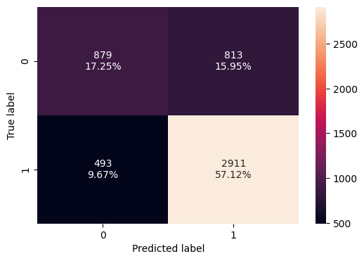

```python
# Checking model performance on validation set
confusion_matrix_sklearn(tuned_gradient_boosting_model, X_val, y_val)
tuned_gradient_boosting_val_perf = model_performance_classification(tuned_gradient_boosting_model, X_val, y_val).copy()
tuned_gradient_boosting_val_perf
```

- On the validation set, tuned Gradient Boosting maintains stable performance with only a small drop from training metrics. The model achieves a strong balance between recall and precision, meaning it identifies a large share of approved cases while keeping false approvals reasonably controlled. The validation confusion matrix reflects this tradeoff, with a high number of correctly predicted approvals and a moderate number of misclassifications for denied cases.

### Hyperparameter Tuning - XGBoost

```python
# Model name
model_name = "XGBoost"

# Create instance of the model
tuned_xgboost_model = clone(models[model_name])

# Set hyperparameters
param_grid={'n_estimators':np.arange(50,110,25),
            'scale_pos_weight':[1,2,5],
            'learning_rate':[0.01,0.1,0.05],
            'gamma':[1,3],
            'subsample':[0.7,0.9]
}

# Set the grid serarch model and parameters
gs_xgb = GridSearchCV(estimator=tuned_xgboost_model, param_grid=param_grid, scoring="f1", cv=5, n_jobs=-1)

# Fit the training (oversampled) dataset
gs_xgb = gs_xgb.fit(X_train_over, y_train_over)

# Get the best estimator
tuned_xgboost_model = gs_xgb.best_estimator_

# Fit the best estimator to the data
tuned_xgboost_model.fit(X_train_over, y_train_over)

print("Best Params (XGBoost):", gs_xgb.best_params_)
print("Best CV F1 (XGBoost):", gs_xgb.best_score_)
```

```
Best Params (XGBoost): {'gamma': 1, 'learning_rate': 0.1, 'n_estimators': np.int64(100), 'scale_pos_weight': 2, 'subsample': 0.7}
Best CV F1 (XGBoost): 0.8270501393165699
```

|  | Accuracy | Recall | Precision | F1 |
| --- | --- | --- | --- | --- |
| 0 | 0.765764 | 0.973457 | 0.75017 | 0.847351 |

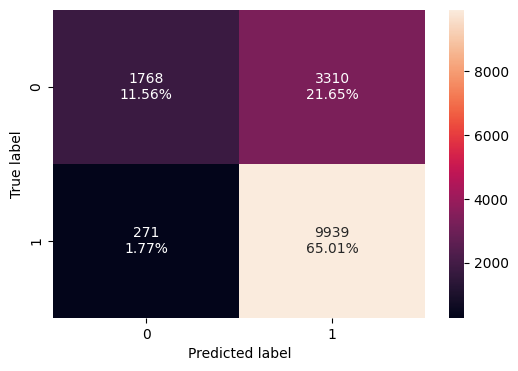

```python
# Checking model performance on training set
confusion_matrix_sklearn(tuned_xgboost_model, X_train, y_train)
tuned_xgboost_train_perf = model_performance_classification(tuned_xgboost_model, X_train, y_train).copy()
tuned_xgboost_train_perf
```

- The training confusion matrix shows the model predicts Approved very aggressively (very high recall), meaning it captures almost all approvals. However, there is a noticeable number of Denied cases predicted as Approved (higher false positives for Approved / false approvals), reflected by the lower precision relative to recall.

#### Checking Model Performance on Validation Set

|  | Accuracy | Recall | Precision | F1 |
| --- | --- | --- | --- | --- |
| 0 | 0.726845 | 0.938308 | 0.72989 | 0.82108 |

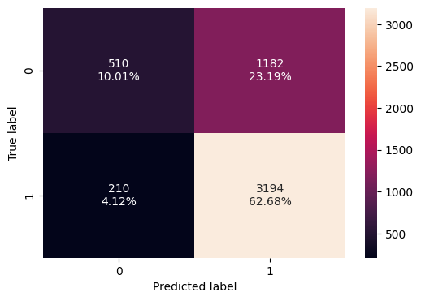

```python
# Checking model performance on validation set
confusion_matrix_sklearn(tuned_xgboost_model, X_val, y_val)
tuned_xgboost_val_perf = model_performance_classification(tuned_xgboost_model, X_val, y_val).copy()
tuned_xgboost_val_perf
```

- On validation, XGBoost still maintains very high recall, but precision remains lower, indicating the same pattern continues. The model tends to label many cases as Approved, which increases the risk of misclassifying Denied cases as Approved. The validation confusion matrix confirms this with a relatively large count of Denied cases being predicted as Approved.

# **Model Comparison and Final Model Selection**

```python
# Add the Model names as a column to each before combining
model_names = [
    "Tuned AdaBoost",
    "Tuned Gradient Boost",
    "Tuned XGBoost"
]
```

#### Training Performance Comparison

```python
# Create a list of your existing performance DataFrames
perf_list = [
    tuned_adaboost_train_perf,
    tuned_gradient_boosting_train_perf,
    tuned_xgboost_train_perf
]

for df, name in zip(perf_list, model_names):
    df["Model"] = name

# Stack them all vertically
models_train_comp_df = pd.concat(perf_list, ignore_index=True)

# Reorder columns to put 'Model' first
cols = ['Model'] + [c for c in models_train_comp_df.columns if c != 'Model']
models_train_comp_df = models_train_comp_df[cols]

display(models_train_comp_df)
```

|  | Model | Accuracy | Recall | Precision | F1 |
| --- | --- | --- | --- | --- | --- |
| 0 | Tuned AdaBoost | 0.801763 | 0.845348 | 0.777568 | 0.810042 |
| 1 | Tuned Gradient Boost | 0.746402 | 0.861802 | 0.781092 | 0.819464 |
| 2 | Tuned XGBoost | 0.765764 | 0.973457 | 0.750170 | 0.847351 |

#### Validation Performance Comparison

```python
# Create a list of your existing performance DataFrames
perf_list = [
    tuned_adaboost_val_perf,
    tuned_gradient_boosting_val_perf,
    tuned_xgboost_val_perf
]

for df, name in zip(perf_list, model_names):
    df["Model"] = name

# Stack them all vertically
models_validation_comp_df = pd.concat(perf_list, ignore_index=True)

# Reorder columns to put 'Model' first
cols = ['Model'] + [c for c in models_validation_comp_df.columns if c != 'Model']
models_validation_comp_df = models_validation_comp_df[cols]

display(models_validation_comp_df)
```

|  | Model | Accuracy | Recall | Precision | F1 |
| --- | --- | --- | --- | --- | --- |
| 0 | Tuned AdaBoost | 0.748626 | 0.839600 | 0.795436 | 0.816922 |
| 1 | Tuned Gradient Boost | 0.743721 | 0.855170 | 0.781686 | 0.816779 |
| 2 | Tuned XGBoost | 0.726845 | 0.938308 | 0.729890 | 0.821080 |

#### Summary of Tuned Model Performance (Train vs Validation):

- Across the tuned models, performance is fairly close on the validation set, but the models differ in how they trade off recall vs precision (positive class as Approved = 1).
- **Tuned AdaBoost**
> - Validation: Accuracy 0.7486 (highest), F1 0.8169, Recall 0.8396, Precision 0.7954 (highest).
> - AdaBoost provides the best precision and the highest accuracy, meaning when it predicts Approved, it is more often correct (fewer false approvals) while still maintaining strong recall.
- **Tuned Gradient Boosting**
> - Validation: Accuracy 0.7437, F1 0.8168, Recall 0.8552, Precision 0.7817.
> - Gradient Boosting offers the most balanced performance with strong recall and solid precision, and it shows a very small train–validation gap, indicating stable generalization.
- **Tuned XGBoost**
> - Validation: Accuracy 0.7268 (lowest), F1 0.8211 (highest), Recall 0.9383 (highest), Precision 0.7299 (lowest).
> - XGBoost achieves the highest recall, capturing the most approvals, but at the cost of lower precision, meaning it is more likely to incorrectly label Denied cases as Approved.

#### Final Model Selection - **Tuned Gradient Boosting**

- A strong final model choice depends on the business tradeoff between catching approvals (recall) and avoiding false approvals (precision). On validation, all three tuned models perform closely, but they differ in this tradeoff.
- **Recommended Final Model:**

> Tuned Gradient Boosting (balanced option) Tuned Gradient Boosting provides one of the best overall balances on validation, with F1 = 0.8168, Recall = 0.8552, and Precision = 0.7817. It generalizes well (small train–validation gap) and offers a strong middle ground between capturing approvals and controlling false approvals.
- **Comparison to XGBoost**

> Compared to XGBoost, Gradient Boosting avoids the very aggressive “approve” tendency. While XGBoost has the highest recall (0.9383) and highest F1 (0.8211), its precision is notably lower (0.7299), meaning it produces more false approvals.
- **Comparison to AdaBoost**

> Compared to AdaBoost, Gradient Boosting achieves higher recall (0.8552 vs 0.8396) but slightly lower precision (0.7817 vs 0.7954) and slightly lower accuracy (0.7437 vs 0.7486). In practice, AdaBoost is a bit more conservative (fewer false approvals), while Gradient Boosting captures more approvals.
- **When would XGBoost be chosen instead?**

> If the business goal is to maximize approvals captured (minimize missing true approvals), XGBoost is a reasonable alternative due to its very high recall (0.9383). However, it comes with more false approvals (lower precision), which can increase downstream risk/cost.

#### Checking Model Performance on Test Set

|  | Accuracy | Recall | Precision | F1 |
| --- | --- | --- | --- | --- |
| 0 | 0.736264 | 0.856052 | 0.773355 | 0.812605 |

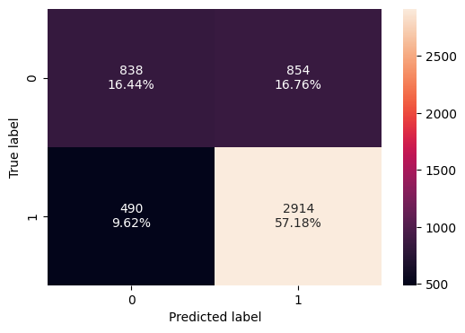

```python
# Checking model performance on test set
confusion_matrix_sklearn(tuned_gradient_boosting_model, X_test, y_test)
tuned_gradient_boosting_test_perf = model_performance_classification(tuned_gradient_boosting_model, X_test, y_test).copy()
tuned_gradient_boosting_test_perf
```

- This indicates the model is strong at correctly identifying Approved cases (high recall), while maintaining reasonable precision. However, the main source of error is Denied cases being predicted as Approved, which suggests the model is somewhat approval-leaning.

#### Feature Importance

[output not shown]

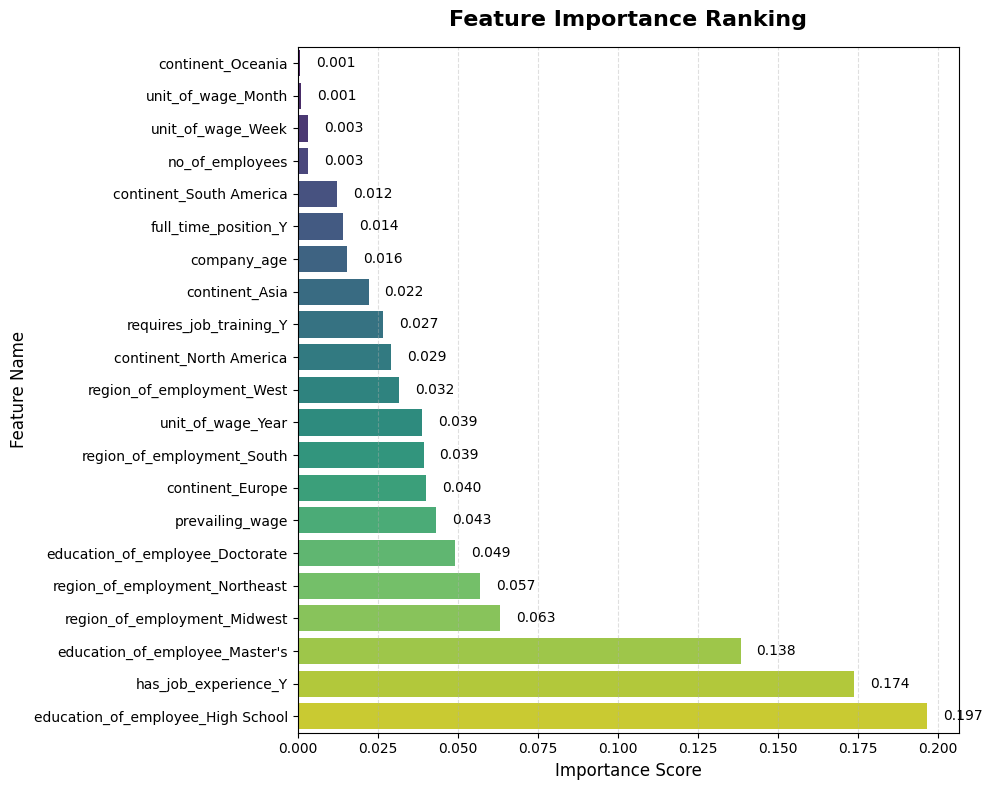

```python
# List all the features from the training set
feature_names = X_train_over.columns.tolist()
print(feature_names)
plot_feature_importance(tuned_gradient_boosting_model, feature_names)
```

# **Actionable Insights and Recommendations**

Based on the results of the EDA, modeling, and feature importance, here are the recommendations:

1. **Education level is the strongest driver of outcomes**
> - Both EDA and the final model highlight `education_of_employee` as the most influential factor. The bivariate plot shows a clear upward trend in certification rate by education. High School has the lowest certification rate (majority denied), followed by Bachelor’s, then Master’s, with Doctorate having the highest certification rate. The most influential feature is `education_of_employee_High School` (0.197), followed by `education_of_employee_Master’s` (0.138) and `education_of_employee_Doctorate` (0.049).
> - **Recommendation**: Use education as a primary triage rule. High School cases should be routed for enhanced review and stronger documentation while Master’s/Doctorate cases can be considered for a fast-track lane.
2. **Prior job experience is a major approval signal**
> - The bivariate plot for `has_job_experience` shows higher certification rates for applicants with job experience = Y, and the model ranks `has_job_experience_Y` among the top drivers (0.174). This indicates that prior experience strongly affects approval predictions and is a key lever to improve approval odds.
> - **Recommendation**: Add a screening rule. If no job experience, require additional supporting evidence (e.g., internship history, projects/portfolio, certifications) while prior job experience cases can be considered for a fast-track lane.
3. **Wage level and unit is an important signal of case strength**
> - Feature importance indicates `prevailing_wage` (0.043) and `unit_of_wage_Year` (0.039) contribute meaningfully. The presence of wage unit features suggests wage structure (year vs week/month) and consistency are relevant signals.
> - **Recommendation**: Implement a wage-based review tier. Lower wage offers require stronger justification and documentation while higher wage offers prioritize for faster processing. Continue enforcing wage standardization (annualized wage) and validate outliers that will improves model reliability and reduces processing errors.
4. **Region of employment has meaningful but secondary influence**
> - `region_of_employment_Midwest` (0.063) and `region_of_employment_Northeast` (0.057) are relatively important compared to other features, indicating regional patterns exist.
> - **Recommendation**: Use region/continent as a secondary prioritization signal. Allocate experienced reviewers to regions/continents with historically higher denial proportions. Develop region specific documentation checklists where patterns suggest certain deficiencies are common.
5. **Job requirements and employment type provide small tie-breaker signals**
> - `requires_job_training_Y` (0.027) and `full_time_position_Y` (0.014) matter, but they are not primary drivers.
> - **Recommendation**: For cases with low wage and low education/experience, training requirement may indicate a readiness gap. In those cases, request a clear training plan and skill alignment evidence. Full-time status can support case strength, but should not override education/experience/wage signals.
6. **Employer profile has modest impact**
> - `company_age` (0.016) and `no_of_employees` (0.003) have low importance, meaning they contribute only minor incremental predictive power.
> - **Recommendation**: Do not overemphasize employer size/age in decisions, but provide extra support to newer/smaller employers (i.e., stronger legitimacy documentation, clearer role description and wage justification, compliance consistency checks).

## Export notebook to .HTML

```python
# To export this notebook as .html for the submission
!jupyter nbconvert --to html '/content/drive/MyDrive/ColabNotebooks/EasyVisa/Project_Full_Code_Notebook_EasyVisa.ipynb'
```

```
[NbConvertApp] Converting notebook /content/drive/MyDrive/ColabNotebooks/EasyVisa/Project_Full_Code_Notebook_EasyVisa.ipynb to html
[NbConvertApp] WARNING | Alternative text is missing on 34 image(s).
[NbConvertApp] Writing 2248639 bytes to /content/drive/MyDrive/ColabNotebooks/EasyVisa/Project_Full_Code_Notebook_EasyVisa.html
```